# Sta 250 homework1

### Problem 1. Convex Sets and Convex Functions

#### Prove whether the following sets of functions are convex or not

#### (a) {$x\in \mathbb{R}^n | Ax=b$} where $A\in \mathbb{R}^{mxn}$,$b\in \mathbb{R}^m$

#### Pf:

$\forall x_1,x_2\in \{x\in \mathbb{R}^n | Ax=b\}$,$\forall \alpha\in[0,1]$,

$$A(\alpha x_1+(1-\alpha)x_2)=\alpha Ax_1+(1-\alpha)Ax_2=\alpha b+(1-\alpha)b=b$$

which means $\alpha x_1+(1-\alpha)x_2\in\{x\in \mathbb{R}^n | Ax=b\}$

So that {$x\in R^n | Ax=b$ where $A\in \mathbb{R}^{mxn}$,$b\in \mathbb{R}^m$} is a convex sets.

#### (b){$x\in \mathbb{R}^n | ||x-x_0||_2=r$},where $x_0\in \mathbb{R}^n,r\in \mathbb{R}$

#### Pf:

let $x_0=[0,0]^T,r=\sqrt5,x_1=[1,2]^T,x_2=[2,1]^T$, so that $x_1,x_2\in \{x\in \mathbb{R}^n | ||x||_2=\sqrt5\}$, $\forall\alpha\in(0,1)$,

$\alpha x_1+(1-\alpha)x_2=[2-\alpha,1+\alpha]^T$,

$$||\alpha x_1+(1-\alpha)x_2||_2=[(2-\alpha)^2+(1+\alpha)]^\frac{1}{2}=(2\alpha^2-2\alpha+5)^\frac{1}{2}\ne\sqrt5$$

So that {$x\in \mathbb{R}^n | ||x-x_0||_2=r$,where $x_0\in \mathbb{R}^n,r\in \mathbb{R}$}is not a convex sets.

#### (c) $f(x_1,x_2)=(x_1x_2-1)^2$, where $x_1,x_2\in \mathbb{R}$

#### Pf:

Let consider $(x_1,x_2)=(1,1),(y_1,y_2)=(0,0)\in \mathbb{R}^2$,$\alpha=0.1\in(0,1)$

$$\begin{eqnarray}
f(\alpha x_1+(1-\alpha)y_1,\alpha x_2+(1-\alpha)y_2)&=&f(0.1,0,1)=(0.1^2-1)^2=0.99^2\\
\alpha f(x_1,x_2)+(1-\alpha)f(y_1,y_2)&=&\alpha f(1,1)+(1-\alpha)f(0,0)=0.9
\end{eqnarray}$$

$0.99*0.99>0.9$, so that $\exists (x_1,x_2),(y_1,y_2)\in \mathbb{R}^2,\exists\alpha\in(0,1),$

$$\alpha f(x_1,x_2)+(1-\alpha)f(y_1,y_2)<f(\alpha x_1+(1-\alpha)y_1,\alpha x_2+(1-\alpha)y_2)$$

So that it is not a convex function.

#### (d)$f(w_1,w_2)=||w_1-w_2||^2_2$, where $w_1,w_2\in\mathbb{R}^2$

#### Pf:

$\forall x_1,x_2,y_1,y_2\in\mathbb{R}^2$,$\forall \alpha\in[0,1]$,

$$\begin{eqnarray}
\alpha f(x_1,x_2)+(1-\alpha)f(y_1,y_2)&=&\alpha||x_1-x_2||^2_2+(1-\alpha)||y_1-y_2||^2_2\\
&=&\sum_{i=1}^2[\alpha(x_{1i}-x_{2i})^2+(1-\alpha)(y_{1i}-y_{2i})^2]\\
f(\alpha x_1+(1-\alpha)y_1,\alpha x_2+(1-\alpha)y_2))&=&\sum_{i=1}^2[\alpha(x_{1i}-x_{2i})+(1-\alpha)(y_{1i}-y_{2i})]^2
\end{eqnarray}$$
Note $X_i=x_{1i}-x_{2i},Y_i=y_{1i}-y_{2i}$

All I need to prove is that $\alpha X_i^2+(1-\alpha)Y_i^2\ge[\alpha X_i+(1-\alpha)Y_i]^2$

It is the same problem as proving $f(x)=x^2$ is a convex function.

$f(x)=x^2$ is a convex function

$\Rightarrow\alpha f(x_1,x_2)+(1-\alpha)f(y_1,y_2)\ge f(\alpha x_1+(1-\alpha)y_1,\alpha x_2+(1-\alpha)y_2))$

$\Rightarrow f(w_1,w_2)$is a convex function

### Problem 2. Stationary points

#### (a) Identify stationary points for $f(x)=2x_1+12x_2+x_1^2-3x_2^2$? Are they local minimum/maximum; global minimum/maximum or saddle points? Why?

Answer:
$$\frac{\partial f(x)}{\partial x_1}=2+2x_1$$
$$\frac{\partial f(x)}{\partial x_2}=12-6x_2$$

let$\triangledown f(x)=0$,we get (-1,2),

$$\triangledown^2f(x)=\begin{bmatrix}2&0\\0&-6\end{bmatrix}$$

the stationary point is (-1,2), it is a saddle point.

#### (b)Assume $f:\mathbb{R}^n\to\mathbb{R}$ is strongly convex and is L-Lipchitz($||\triangledown f(x)-\triangledown f(y)||_2\le L||x-y||_2$) for any (x,y). Given an n by n symmetric matrix B with $MI\succeq B\succeq mI$ with $M\ge m>0$, provide a valid step size $\eta$ such that the sequence $$x^{k+1}=x^k-\eta B\triangledown f(x^k)$$ converges to the minimizers of f.

The function is strongly covex and is L-Lipchitz $\Rightarrow$ all limit points are stationary points, all the stationary points are the global minimizers.

let $x^+=x^{k+1},x=x^{k}$

$$\begin{eqnarray}
f(x^+)&\le& f(x)+\triangledown f(x)^T(x^+-x)+\frac{L}{2}||x^+-x||^2\\
&=&f(x)+\triangledown f(x)^T(-\eta B\triangledown f(x))+\frac{L}{2}||-\eta B\triangledown f(x)||^2\\
&=&f(x)-\triangledown f(x)^T(\eta I-\frac{L\eta^2}2 B^T)B\triangledown f(x)
\end{eqnarray}$$
$\Rightarrow (\eta I-\frac{L\eta^2}2 B^T)B$ should be a positive definite matrix

### Problem 3. Gradient Descent

Given training data $\{x_i,y_i\}^n_{i=1}$, each $x_i\in\mathbb{R}^d$ and $y_i\in\{+1,-1\}$, we try to solve the following logistic regression problem by gradient descent:
$$\min_{w\subset\mathbb{R}^d}\{\frac{1}{n}\sum_{i=1}^n\log(1+e^{-y_iw^Tx_i})+\frac12||w||^2_2\}:=f(w).
\tag1$$
Test the algorithm using the “heart_scale” datasetwith n = 270 and d = 13: the matrix X is stored in the file “X_heart”, and the vector y is stored in the file “y_heart”.

#### (a)

Implement the gradient descent algorithm with a fixed step size $\eta$. Find a small $\eta_1$ such that the algorithm converges. Increase the step size to $\eta_2$ so the algorithm cannot converge. Run 50 iterations and plot the iteration versus $log(f(x^k)-f(x^*))$ plot for $\eta_1$ and $\eta_2$. In practice it is impossible to get the exact optimal solution $x^*$, So use the minimum value you computed as $f(x^*)$ when you plot the figure. Report the $f(x^*)$ value you used for generating the plots.

```r
#read data
x<-read.table('E:/hw1_data/X_heart')
y<-read.table('E:/hw1_data/y_heart')
#add a constant variables
x<-cbind(1,x)
#the number of samples
n=nrow(x)
#the number of variables
p=ncol(x)
#iteration times
k=50
```

$$\triangledown f(w) =\frac{1}{n} \sum_{i=1}^n \frac{-y_ie^{-y_iw^Tx_i}}{1+e^{-y_iw^Tx_i }}x_i+W$$

```r
#set f'(w) as a function
fw1<-function(w){
    #calculate f'(w)
    fw=0
    for (i in 1:n){
      e=exp(-y[i,]*t(w)%*%t(x[i,]))
      fw=fw+t((-y[i,]*e)/(1+e)*x[i,])
    }
    fw=fw/n+w
    fw
}
```

```r
#set f(w) as a function
fw<-function(w){
  f=1/2*sum(w^2)
  for (i in 1:n){
    f=f+1/n*log(1+exp(-y[i,]*t(w)%*%t(x[i,])))
  }
  f
}
```

```r
#initial w
w=matrix(1, p, 1)
#To record w
wlist=matrix(0,p,(k+1))
wlist[,1]=w
#set eta
eta=0.1

for(j in 1:k){
  w=w-eta*fw1(w)#the new w
  wlist[,j+1]=w#record w
}
```

```r
flist=vector(mode='numeric',k+1)
for (j in 1:(k+1)) {
  flist[j]=fw(wlist[,j])}
```

```r
min(flist)
```

```
## [1] 0.6184942
```

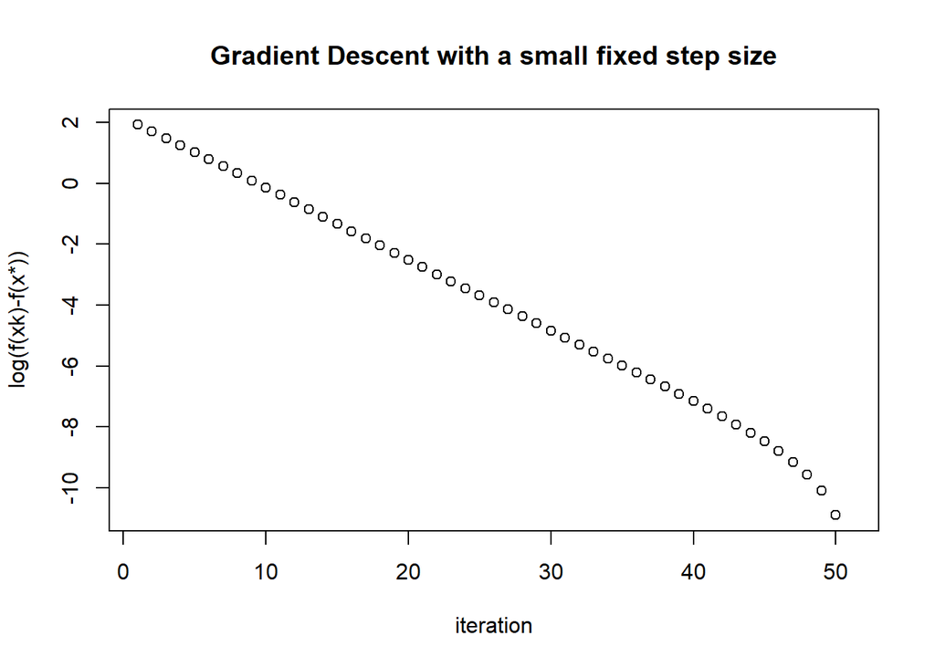

```r
plot(log(flist-min(flist)),xlab = "iteration",ylab = "log(f(xk)-f(x*))",main = "Gradient Descent with a small fixed step size")
```

```r
#initial w
w=matrix(1, p, 1)
#To record w
wlist=matrix(0,p,(k+1))
wlist[,1]=w
#set eta
eta=1.5

for(j in 1:k){
  w=w-eta*fw1(w)#the new w
  wlist[,j+1]=w#record w
}
```

```r
flist=vector(mode='numeric',k+1)
for (j in 1:(k+1)) {
  flist[j]=fw(wlist[,j])}
```

```r
min(flist)
```

```
## [1] 2.894975
```

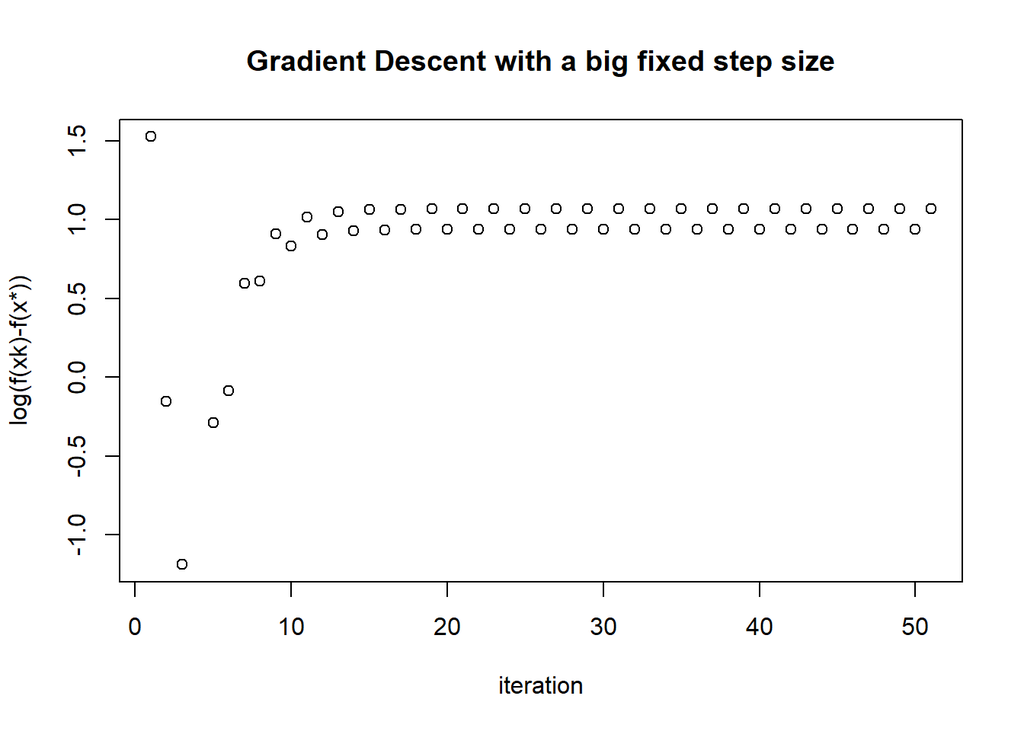

```r
plot(log(flist-min(flist)),xlab = "iteration",ylab = "log(f(xk)-f(x*))",main = "Gradient Descent with a big fixed step size")
```

#### (b)

Implement the gradient descent algorithm with backtracking line search. Plot the same iteration versus $log(f(x^k)-f(x^*))$

```r
#initial w
w=matrix(1, p, 1)
#To record w
wlist=matrix(0,p,(k+1))
wlist[,1]=w

for(j in 1:k){
  g=fw1(w)
  eta=1
  while(fw(w-eta*g)-fw(w)>-0.01*eta*sum(g^2)){
    eta=eta/2
  }
  w=w-eta*g#the new w
  wlist[,j+1]=w#record w
}
```

```r
flist=vector(mode='numeric',k+1)
for (j in 1:(k+1)) {
  flist[j]=fw(wlist[,j])}
```

```r
min(flist)
```

```
## [1] 0.6184192
```

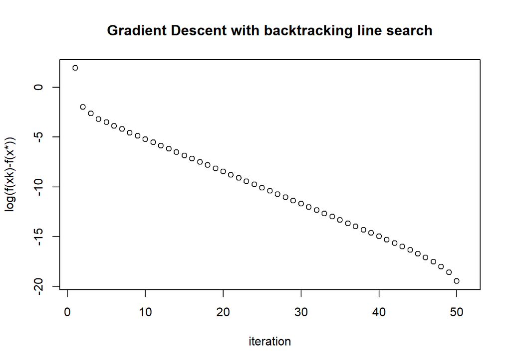

```r
plot(log(flist-min(flist)),xlab = "iteration",ylab = "log(f(xk)-f(x*))",main = "Gradient Descent with backtracking line search")
```